# Is there Enough Evidence of a Sixth Mass Extinction?

Erinne Yoo

## Integrating IUCN’s API

**Introduction to Mass Extinction:**  
Paleontologists characterize mass extinctions as periods when the Earth loses more than three-quarters of its species in a “geologically short interval”. What defines a short interval? 2 million years or less. The Big Five (Cretaceous, Triassic, Permian, Devonian, Ordovician, from recent to oldest) account for 10% of the total extinctions (Jablonski 1995) and have a spaced interval of 50-100 million years. Cretaceous period ended with the asteroid impact, 65 million years ago. However humans have altered the landscape since the Pleistocene. Researchers have speculated that carbon emissions, habitat loss, disease, greenhouse gases have increased in a rate that is unsustainable. To test these claims we utilize information to create legible visual data and draw analyses.

### First steps Cracking Open the API

Here we make an Rest API request to retrieve JSON formatted information to eventually tabular data.

To locate the species count API, find the section ‘Species Count’ with the hyperlink showing ‘Example: Total Count’ in the IUCN’s Red List API. Using the endpoint, we can narrow species information by region, id, category, and other classifications. `GET` is a function from package `httr` which we need to retrieve the requested information. `content` is another function applied to extract info from the request. We then compartmentalize the URL into a base, endpoint, token: ‘base’ is analogous to a package name, ‘endpoint’ a function name, and ‘url’ to a function call.

```r
resp <- GET("https://apiv3.iucnredlist.org/api/v3/speciescount?token=9bb4facb6d23f48efbf424bb05c0c1ef1cf6f468393bc745d42179ac4aca5fee")
#in this long address above we want to break this long string of text
base <- "https://apiv3.iucnredlist.org/api/v3"
endpoint <- "speciescount"
token <- "9bb4facb6d23f48efbf424bb05c0c1ef1cf6f468393bc745d42179ac4aca5fee"
url <- glue("{base}/{endpoint}?token={token}")
req <- GET(url)
x<- content(req) #x$speciescount to view how many species
```

To get information of all species id and taxonomy, we use its different endpoint. The IUCN instructs the list of all the species and the Red List category be requested based on pages. Function `paste0` will create a convenient list of the page (16 total pages) to be appended into the full url. The pages follow the format: “https://apiv3.iucnredlist.org/api/v3/species/page/0?token=9bb4facb6d23f48efbf424bb05c0c1ef1cf6f468393bc745d42179ac4aca5fee” and will be fed into a loop that will store the information into an `rds` (R Data Serialization).

```r
species_endpoint<- "species"
page <- paste0("page/", 0:15)
all_pages <- glue("{base}/{species_endpoint}/{page}?token={token}")
```

The URL’s have their contents extracted in this function which speeds the process by ensuring all_species.rds exists. Otherwise, this `if` loop requests GET as long long as there are no errors.

```r
if(!file.exists("all_species.rds")) {
  all_species <- map(all_pages, GET, .progress = TRUE)
  status <- map_int(all_species, status_code)
  stopifnot(all(status < 400))
  write_rds(all_species, "all_species.rds")
}
```

The if loop created a file called `all_species`, a response object in JSON structure, and `all_resp` takes that JSON and gets the summary information content.

```r
all_species <- read_rds("all_species.rds")
all_resp <- map(all_species, content, encoding = "UTF-8")
```

**Creating the data table** Given the list of species and resp, you can construct a dataframe with the columns: scientific name, category, class, phylum. There were 16 pages of content so we iterate over each page, using package `purrr`’s `map_chr` to get its result and the specific categories.

```r
sci_name <- map(all_resp, \(page) map_chr(page$result, "scientific_name")) |> list_c()
category <- map(all_resp, \(page) map_chr(page$result, "category")) |> list_c()
class <-  map(all_resp, \(page) map_chr(page$result, "class_name")) |> list_c()
phylum <-  map(all_resp, \(page) map_chr(page$result, "phylum_name")) |> list_c()

all_species <- tibble(sci_name, category, class, phylum)
```

9 categories or tiers of threatened status: Not Evaluated (NE), Data Deficient (DD), Least Concern (LC), Near Threatened (NT), Vulnerable (VU), Endangered (EN), Critically Endangered (CR), Extinct in the Wild and Extinct (EX). Filtering the category equal to “EX” will select the extinct species from the table `all_species` that we just created.

```r
extinct_species<- all_species |> filter(category=="EX")
```

Take the column (that is a list of all scientific names) and use this long glued list to encode next.

```r
sp <- extinct_species$sci_name
```

`map` works like a loop, applying the HTTR function `content` over extinct species to extract information into a string. The `narrative_population` is a short verbal description or sighting noting when a species was declared extinct, where last observed, and/or cause of overall death. Not all species have field note entries, however.

```r
narrative_contents <- map(ex_narrative, content) #HTTR function content
narrative_population <- map(narrative_contents, \(x) map_chr(x$result[1], "population", .default = ""))
narrative_rationale <- map(narrative_contents, \(x) x$result[[1]]$rationale)
#for guidance refer to rstudio.github.io/cheatsheets/string.pdf
```

Using narrative_population from above, we use function `map_chr` that loops to convert a particular match of text into integer. Through Regex commands: we take strings that have exactly 4 digits in a row, indicating years. We assume that if there is such match, the numeric character mentioned is referencing the latest recorded year of the species.

```r
last_seen<-narrative_population |>
  map_chr(str_extract, "\\d{4}" ) |>
  as.integer()

extinction_dates <- tibble(sci_name=ext_sci_name,last_seen) |> distinct()
combined <- all_species |> left_join(extinction_dates)
```

Since we are interested in grouping into taxonomic classes of cartilaginous vertebrates (mammals, birds, amphibians, reptiles, and fish) we select the 5 classes and save it to `total_sp`. We will use this class grouped total to calculate the extinction msy per taxonomic class.

```r
total_sp <- combined |>
  filter(class %in% c("MAMMALIA", "AVES", "AMPHIBIA", "REPTILIA", "ACTINOPTERYGII")) |>
  count(class, name = "total")
```

In order to make a visual plot illustrating the increase in E/MSY over time, we need to first make a table that calculates this column: The number of occurrences of the five main classes is the total, `replace_na` is a `tidyverse` function that will replace missing `last_seen` values with the current year, 2023. However, this may be slightly inaccurate because some extinct species with insufficient data may be misrepresented and falsely stamped as last seen in 2023. For example *Ectopistes migratorius* and *Thylacinus cynocephalus* went extinct in the 20th century but are marked as extinct in the 21st. However, we will overlook this for the sake of the assignment

```r
final_tbl <-
  combined |>
  filter(category == "EX") |>
  filter(class %in% c("MAMMALIA", "AVES", "AMPHIBIA", "REPTILIA", "ACTINOPTERYGII")) |>
  mutate(last_seen = replace_na(last_seen, 2023),
         century =  str_extract(last_seen, "\\d{2}")) |>
  count(century, class) |> left_join(total_sp) |>
  mutate(extinction_msy = n / total * 10000) # extinctions per million-species-years
#final_tbl
```

## Recreating Ceballos et. al Graph

- from *Accelerated modern human–induced species losses: Entering the sixth mass extinction* [Ceballos et al (2015)](http://doi.org/10.1126/sciadv.1400253)

**Figure 1**  
This graph is inspired by Ceballos and colleagues, which shows extinction rates across centuries.

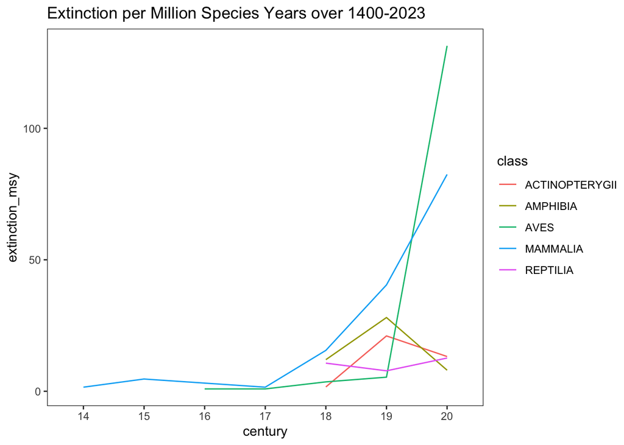

```r
final_tbl %>% filter(class %in% c("MAMMALIA", "AVES", "ACTINOPTERYGII", "AMPHIBIA", "REPTILIA")) %>%  ggplot( aes(x = century, y = extinction_msy, color = class, group = class)) +
  geom_line()  +   theme_test() + ggtitle("Extinction per Million Species Years over 1400-2023 ")
```

**Extinction/Million Species Years and The Main Cause of Decline for each Vertebrate Class:**

Actinopterygii or finned fish: reasons for extinction include habitat loss, water abstraction, drained lakes, according to the IUCN assessments. Nearly all causes are attributed to human-interfered events, such as the introduction of non-native species, polluted lakes, irrigation projects, and overfishing. It is to be noted that a majority of the declared species tallied in the IUCN are freshwater fishes, highlighting insufficient available aquatic species.

Amphibians: Disease outbreak and habitat loss are the leading causes accounting for for 91% of amphibian declines among recent deteriorating amphibian populations. Chytridiomiosis caused by *Batrachochytrium dendrobatidis*, a fungus, emerging as early as 1938 (Weldon 2004) impacts frogs’ skins. Although the table results presents only 36 lost amphibian species over the past 500 years, 723 species are critically endangered (10%) and another 1,144 (15%) are endangered.

Mammalia: Rodents and bovidae constitute a large majority of extinct mammals, who died due to the impact of colonization parallel to birds of the 20th century.

Reptilia: Contributing factors are habitat loss, exploitation, and predation.

[figure not shown]

While the graph constructed in Figure 1 shows the change in MSY over time, Ceballos cumulative graph shows the proportion of extinctions over time (the number of total species extinct at the year over the total number of species documented since 1500). Out of the percentage of vertebrates, the percentage of extinct mammals and birds outweigh the proportion of other vertebrates, most likely due to K-selected speciation meaning sparse gestation intervals and less offspring implying less time for a population rebound, as well as overlapping habitats that directly conflict with human interests.

**Documented Extinctions Under Water?**  
Although the main five classes in Figure 1 show the important terrestrial and aquatic animals, it still omitted other aquatic invertebrates. Out of the 36 phyla, we are given information of 19 phyla. I decided to focus on mollusca (octopus and clams), cnidaria (jellyfish), to see how the ocean’s biodiversity has been affected.  
**Figure 2**

```r
total_phylum_aqua <- combined |> filter(phylum %in% c("MOLLUSCA", "ECHINODERMATA", "CNIDARIA")) |> count(phylum, name = "total")

final_tbl_aqua <-
  combined |> filter(category == "EX") |> filter(phylum %in% c("MOLLUSCA", "ECHINODERMATA", "CNIDARIA")) |>
  mutate(last_seen = replace_na(last_seen, 2023), century =  str_extract(last_seen, "\\d{2}")) |>
  count(century, phylum) |> left_join(total_phylum_aqua) |> mutate(extinction_msy = n / total * 10000)
final_tbl_aqua
```

```
# A tibble: 3 × 5
  century phylum       n total extinction_msy
  <chr>   <chr>    <int> <int>          <dbl>
1 18      MOLLUSCA     4  9133           4.38
2 19      MOLLUSCA    29  9133          31.8
3 20      MOLLUSCA   272  9133         298.
```

```
FALSE Scale for fill is already present.
FALSE Adding another scale for fill, which will replace the existing scale.
```

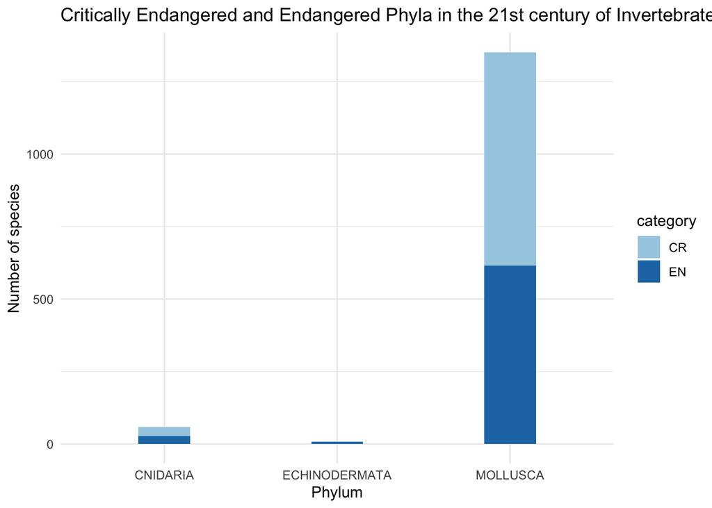

```r
ggplot(data=en_cr_tbl_aqua, aes(x=phylum, y=n, fill=category)) +
  geom_bar(stat="identity", width=0.3) + scale_fill_hue(c = 40) + ggtitle("Critically Endangered and Endangered Phyla in the 21st century of Invertebrates") + labs(x="Phylum", y = "Number of species") + scale_fill_brewer(palette="Paired")+theme_minimal()
```

Interestingly, no cnidaria and echinoderms went extinct over the past 500 years on paper. Even if there were undocumented jellyfish, the difference between observed cnidarian and mollusk survival is very stark. Despite documentaries and agencies emphasizing the rapid decline of reefs (NASA estimates 14% of reefs lost since 2009), the reasons could range from the simple anatomy of cnidarians: Anthozoa (commonly seen as corals, anemones, polyps) and Medusozoa (jellyfish) have high metabolism and no organs. But given that cnidarians require moderately warm temperatures, (around 70-80 Fahrenheit), the global temperature increase could put them in risk- coral bleaching demonstrates the cnidarian’s inability to tolerate warmer waters. Mollusk extinction count on the other hand, is actually largely due to nonmarine organisms. Lydeard et. al cites Polynesian colonization and the subsequent agricultural urban development as one major cause of the decline. Habitat modification like the replacement of unsuitable plant species and introduction of predator rats or even other assassin snails.

## How many species were declared extinct since 1500?

```r
total_ex_sp <- combined |>
  filter(class %in% c("MAMMALIA", "AVES", "AMPHIBIA", "REPTILIA", "ACTINOPTERYGII")) %>% filter(category=="EX") %>%
  count(class, name = "total")
total_ex_sp
```

```
# A tibble: 5 × 2
  class          total
  <chr>          <int>
1 ACTINOPTERYGII    87
2 AMPHIBIA          36
3 AVES             159
4 MAMMALIA          94
5 REPTILIA          32
```

### How about endangered?

```r
everything_table <-
  combined |> filter(class %in% c("GASTROPODA","BIVALVIA", "ACTINOPTERYGII", "REPTILIA", "INSECTA", "ARACHNIDA", "AMPHIBIA", "AVES", "MAMMALIA")) |>
  filter(category%in% c("EX", "CR", "EW", "EN", "VU", "NT", "LC", "DD","NE")) |>
  count(category, class) |>
  left_join(total_sp)
```

```
FALSE Joining with `by = join_by(class)`
```

```
FALSE Scale for fill is already present.
FALSE Adding another scale for fill, which will replace the existing scale.
```

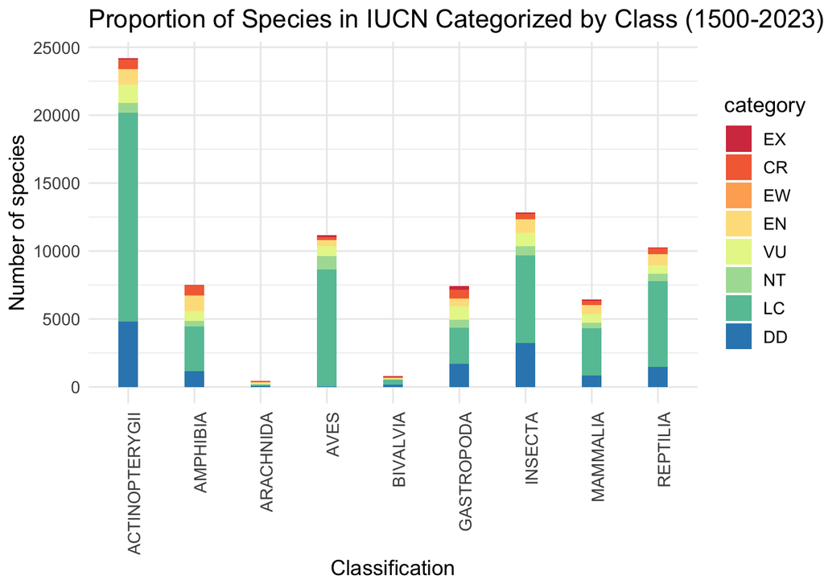

```r
everything_table <- everything_table %>%
  mutate(category =  factor(category, levels = c("EX", "CR", "EW", "EN", "VU", "NT", "LC", "DD","NE"))) %>%
  arrange(category)

ggplot(data=everything_table, aes(x=class, y=n, fill=category)) +
  geom_bar(stat="identity", width=0.3) + scale_fill_hue(c = 40) + ggtitle("Proportion of Species in IUCN Categorized by Class (1500-2023)") + labs(x="Classification", y = "Number of species") + scale_fill_brewer(palette="Spectral")+theme_minimal()  +theme(text = element_text(size=13), axis.text.x = element_text(angle=90, hjust=1))
```

## Next Steps

Some researchers accuse the IUCN of being biased (Cowie 2022) due to invertebrate counts being underrepresented. The IUCN declares a taxon extinct only after thorough surveys and some aquatic species have not been discovered or thoroughly tracked; the NOAA estimates less than 20% of the ocean’s true number of species have yet to be classified. Unfortunately, discovering more species will require funding. The dates from the IUCN are missing and more accurate analyses can be done, perhaps by obtaining a Google search API with Regex to filter keywords that have the word ‘extinct’ and a 4 consecutive numeric across sites. To manually observe regions, you could an endpoint variable with `region/list`, to get the list of available country indexes. Use the `if` function and `purrr` function `map` to loop over all pages based on regions for the purpose of comparing the countries ranked on most endangered statuses.

#### Computational Topics Recap

- Accessing data from a RESTful API
- Error handling
- JSON data format
- Regular expressions
- Working with missing values

#### Additional references:

- http://www.hhmi.org/biointeractive/biodiversity-age-humans (Video)
- [Barnosky et al. (2011)](http://doi.org/10.1038/nature09678)
- [Pimm et al (2014)](http://doi.org/10.1126/science.1246752)
- [Sandom et al (2014)](http://dx.doi.org/10.1098/rspb.2013.3254)
- [Weldon et al (2004)](http://doi.org/10.3201/eid1012.030804)
- Lydeard et al (2004)